# Taylor's Theorem: An Underdog in Machine Learning

*How a 300-year-old result quietly powers two of the most important algorithms in modern ML*

## Introduction

Ask any ML practitioner to name the mathematical pillars of their field and you will hear: linear algebra, probability theory, calculus, maybe a touch of information theory. Taylor's theorem rarely makes the list. It sits quietly in undergraduate analysis textbooks, sandwiched between mean value theorems and power series, often dismissed as a tool for approximating sine and cosine. And yet, once you look carefully, it is lurking at the heart of two of the most consequential ideas in machine learning: **gradient descent** and **XGBoost**.

This article is a case for giving Taylor's theorem the credit it deserves. We will state it precisely, derive the approximations it enables, and trace exactly how those approximations give rise — with mathematical honesty — to the update rules and objective functions that practitioners use every day.

## 1. Taylor's Theorem: The Precise Statement

Let $f: \mathbb{R} \to \mathbb{R}$ be $(n+1)$-times continuously differentiable on an open interval containing $a$. Then for any $x$ in that interval:

$$ f(x) = \sum_{k=0}^{n} \frac{f^{(k)}(a)}{k!}(x - a)^k + R_n(x) $$

where the **Lagrange remainder** is:

$$ R_n(x) = \frac{f^{(n+1)}(\xi)}{(n+1)!}(x - a)^{n+1} $$

for some $\xi$ strictly between $a$ and $x$.

The multivariate extension — what machine learning actually needs — replaces $x \in \mathbb{R}$ with $\boldsymbol{\theta} \in \mathbb{R}^d$. For a loss $\mathcal{L}: \mathbb{R}^d \to \mathbb{R}$ that is twice continuously differentiable, expanding around a point $\boldsymbol{\theta}_0$:

$$ \mathcal{L}(\boldsymbol{\theta}) = \mathcal{L}(\boldsymbol{\theta}_0) + \nabla \mathcal{L}(\boldsymbol{\theta}_0)^\top (\boldsymbol{\theta} - \boldsymbol{\theta}_0) + \frac{1}{2}(\boldsymbol{\theta} - \boldsymbol{\theta}_0)^\top \mathbf{H}(\boldsymbol{\theta}_0)(\boldsymbol{\theta} - \boldsymbol{\theta}_0) + \mathcal{O}(\|\boldsymbol{\theta} - \boldsymbol{\theta}_0\|^3) $$

where $\nabla \mathcal{L}(\boldsymbol{\theta}_0) \in \mathbb{R}^d$ is the **gradient vector** and $\mathbf{H}(\boldsymbol{\theta}_0) \in \mathbb{R}^{d \times d}$ is the **Hessian matrix** with entries $H_{ij} = \frac{\partial^2 \mathcal{L}}{\partial \theta_i \partial \theta_j}$.

This is the master equation. Everything that follows is a consequence of choosing how many terms to keep, and what to do with the result.

### Visualizing the Approximation

To build intuition, here is a Taylor approximation of $f(x) = \sin(x)$ at $a = 0$ up to the 5th order. Notice how each additional term tightens the fit around the expansion point — exactly the mechanism we exploit in optimization.

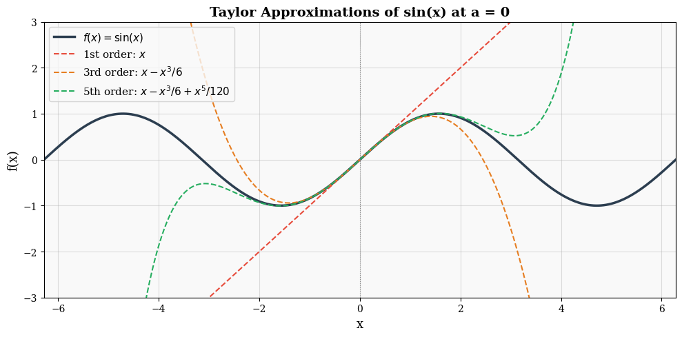

```python
import numpy as np
import matplotlib.pyplot as plt
from matplotlib import rcParams

rcParams['figure.facecolor'] = 'white'
rcParams['axes.facecolor'] = '#f9f9f9'
rcParams['font.family'] = 'serif'

x = np.linspace(-2*np.pi, 2*np.pi, 500)
f = np.sin(x)

# Taylor approximations of sin(x) at a=0
t1 = x                                         # order 1
t3 = x - x**3/6                               # order 3
t5 = x - x**3/6 + x**5/120                    # order 5

fig, ax = plt.subplots(figsize=(10, 5))
ax.plot(x, f,  color='#2c3e50', lw=2.5, label=r'$f(x) = \sin(x)$')
ax.plot(x, t1, color='#e74c3c', lw=1.5, ls='--', label=r'1st order: $x$')
ax.plot(x, t3, color='#e67e22', lw=1.5, ls='--', label=r'3rd order: $x - x^3/6$')
ax.plot(x, t5, color='#27ae60', lw=1.5, ls='--', label=r'5th order: $x - x^3/6 + x^5/120$')

ax.axvline(0, color='gray', lw=0.8, ls=':')
ax.set_ylim(-3, 3)
ax.set_xlim(-2*np.pi, 2*np.pi)
ax.set_xlabel('x', fontsize=13)
ax.set_ylabel('f(x)', fontsize=13)
ax.set_title("Taylor Approximations of sin(x) at a = 0", fontsize=14, fontweight='bold')
ax.legend(fontsize=11)
ax.grid(True, alpha=0.4)
plt.tight_layout()
plt.show()
```

The key takeaway: a 1st-order Taylor expansion is just a tangent line. A 2nd-order expansion is a parabola fitted to the local curvature. Gradient descent uses the tangent line. XGBoost uses the parabola. Everything else follows from that choice.

## 2. Gradient Descent: The First-Order Truncation

### 2.1 The Setup

Let $\mathcal{L}(\boldsymbol{\theta})$ be a differentiable loss we wish to minimize over $\boldsymbol{\theta} \in \mathbb{R}^d$. We are at current iterate $\boldsymbol{\theta}_t$ and want to compute $\boldsymbol{\theta}_{t+1}$. Apply the first-order Taylor expansion around $\boldsymbol{\theta}_t$:

$$ \mathcal{L}(\boldsymbol{\theta}) \approx \mathcal{L}(\boldsymbol{\theta}_t) + \nabla \mathcal{L}(\boldsymbol{\theta}_t)^\top (\boldsymbol{\theta} - \boldsymbol{\theta}_t) $$

This approximation holds when $\|\boldsymbol{\theta} - \boldsymbol{\theta}_t\|$ is small.

### 2.2 The Constrained Minimization

We want to choose a direction $\boldsymbol{\delta} = \boldsymbol{\theta} - \boldsymbol{\theta}_t$ that minimizes the linear approximation subject to a step-size constraint:

$$ \min_{\boldsymbol{\delta}} \; \nabla \mathcal{L}(\boldsymbol{\theta}_t)^\top \boldsymbol{\delta} \quad \text{subject to} \quad \|\boldsymbol{\delta}\| \leq \eta $$

By the **Cauchy–Schwarz inequality**:

$$ \nabla \mathcal{L}(\boldsymbol{\theta}_t)^\top \boldsymbol{\delta} \;\geq\; -\|\nabla \mathcal{L}(\boldsymbol{\theta}_t)\| \cdot \|\boldsymbol{\delta}\| $$

with equality when $\boldsymbol{\delta} = -\eta \frac{\nabla \mathcal{L}(\boldsymbol{\theta}_t)}{\|\nabla \mathcal{L}(\boldsymbol{\theta}_t)\|}$. Absorbing the normalizing constant into a scalar learning rate $\alpha > 0$:

$$ \boxed{\boldsymbol{\theta}_{t+1} = \boldsymbol{\theta}_t - \alpha \, \nabla \mathcal{L}(\boldsymbol{\theta}_t)} $$

This is **gradient descent**. It is not a heuristic. It is the exact solution to minimizing a first-order Taylor approximation of the loss under a norm constraint.

### 2.3 What Gets Thrown Away

Gradient descent discards the quadratic term:

$$ \frac{1}{2}(\boldsymbol{\theta} - \boldsymbol{\theta}_t)^\top \mathbf{H}(\boldsymbol{\theta}_t)(\boldsymbol{\theta} - \boldsymbol{\theta}_t) $$

When the loss landscape is highly curved (large eigenvalues of $\mathbf{H}$), this discarded term is large, and gradient descent oscillates or converges slowly. The learning rate $\alpha$ is a proxy for curvature — when tuned correctly, it implicitly compensates for the missing Hessian information.

### Visualizing Gradient Descent on a 2D Loss Surface

The right panel shows the 1D mechanism directly. At the current iterate $\theta_t$, the first-order Taylor expansion is a tangent line. Gradient descent steps in the direction this tangent line descends, landing at $\theta_{t+1}$. When the true loss curves sharply, the tangent is a poor approximation of what lies ahead.

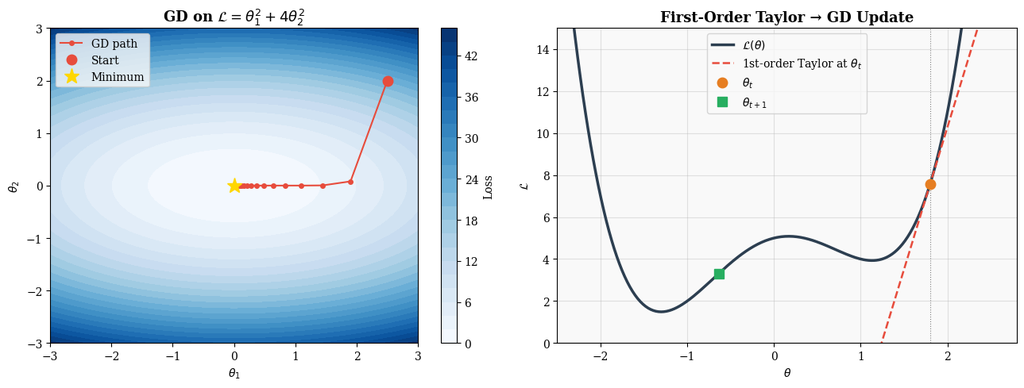

```python
fig, axes = plt.subplots(1, 2, figsize=(13, 5))

# --- Left: loss surface with GD path ---
x1 = np.linspace(-3, 3, 300)
x2 = np.linspace(-3, 3, 300)
X1, X2 = np.meshgrid(x1, x2)
L = X1**2 + 4*X2**2   # elliptic bowl — anisotropic curvature

ax = axes[0]
cp = ax.contourf(X1, X2, L, levels=25, cmap='Blues')
plt.colorbar(cp, ax=ax, label='Loss')

# GD path
theta = np.array([2.5, 2.0])
alpha = 0.12
path = [theta.copy()]
for _ in range(30):
    grad = np.array([2*theta[0], 8*theta[1]])
    theta = theta - alpha * grad
    path.append(theta.copy())
path = np.array(path)

ax.plot(path[:,0], path[:,1], 'o-', color='#e74c3c', ms=4, lw=1.5, label='GD path')
ax.plot(path[0,0], path[0,1], 'o', color='#e74c3c', ms=9, label='Start')
ax.plot(0, 0, '*', color='gold', ms=14, label='Minimum')
ax.set_title(r'GD on $\mathcal{L} = \theta_1^2 + 4\theta_2^2$', fontsize=13, fontweight='bold')
ax.set_xlabel(r'$\theta_1$'); ax.set_ylabel(r'$\theta_2$')
ax.legend(fontsize=10)

# --- Right: 1D loss + Taylor approximation ---
ax2 = axes[1]
x = np.linspace(-3, 3, 400)
f = x**4 - 3*x**2 + x + 5

a = 1.8
fa = a**4 - 3*a**2 + a + 5
dfa = 4*a**3 - 6*a + 1

t1 = fa + dfa*(x - a)

ax2.plot(x, f, color='#2c3e50', lw=2.5, label=r'$\mathcal{L}(\theta)$')
ax2.plot(x, t1, color='#e74c3c', lw=1.8, ls='--', label=r'1st-order Taylor at $\theta_t$')
ax2.axvline(a, color='gray', lw=0.8, ls=':')
ax2.plot(a, fa, 'o', color='#e67e22', ms=9, label=r'$\theta_t$')
next_theta = a - 0.18 * dfa
ax2.plot(next_theta, next_theta**4 - 3*next_theta**2 + next_theta + 5,
         's', color='#27ae60', ms=9, label=r'$\theta_{t+1}$')
ax2.set_ylim(0, 15); ax2.set_xlim(-2.5, 2.8)
ax2.set_title('First-Order Taylor → GD Update', fontsize=13, fontweight='bold')
ax2.set_xlabel(r'$\theta$'); ax2.set_ylabel(r'$\mathcal{L}$')
ax2.legend(fontsize=10)
ax2.grid(True, alpha=0.35)

plt.tight_layout()
plt.show()
```

## 3. XGBoost: The Second-Order Full Treatment

### 3.1 The Boosting Framework

XGBoost builds an ensemble of $T$ trees additively:

$$ \hat{y}_i^{(T)} = \sum_{t=1}^{T} f_t(\mathbf{x}_i), \quad f_t \in \mathcal{F} $$

At iteration $t$, trees $f_1, \ldots, f_{t-1}$ are fixed. We choose $f_t$ to minimize:

$$ \mathcal{L}^{(t)} = \sum_{i=1}^{n} \ell\!\left(y_i,\; \hat{y}_i^{(t-1)} + f_t(\mathbf{x}_i)\right) + \Omega(f_t) $$

### 3.2 Taylor Expansion of the Objective

Expand $\ell\!\left(y_i, \hat{y}_i^{(t-1)} + f_t(\mathbf{x}_i)\right)$ as a second-order Taylor series in $f_t(\mathbf{x}_i)$ around $\hat{y}_i^{(t-1)}$:

$$ \ell\!\left(y_i,\; \hat{y}_i^{(t-1)} + f_t(\mathbf{x}_i)\right) \approx \ell\!\left(y_i, \hat{y}_i^{(t-1)}\right) + g_i\, f_t(\mathbf{x}_i) + \frac{1}{2}\, h_i\, f_t(\mathbf{x}_i)^2 $$

where:

$$ g_i = \frac{\partial\, \ell(y_i, \hat{y})}{\partial \hat{y}}\Bigg|_{\hat{y} = \hat{y}_i^{(t-1)}}, \qquad h_i = \frac{\partial^2 \ell(y_i, \hat{y})}{\partial \hat{y}^2}\Bigg|_{\hat{y} = \hat{y}_i^{(t-1)}} $$

$g_i$ is the **first-order gradient** (residual signal); $h_i$ is the **second-order gradient** (local curvature). Dropping the constant $\ell(y_i, \hat{y}_i^{(t-1)})$:

$$ \tilde{\mathcal{L}}^{(t)} = \sum_{i=1}^{n} \left[ g_i f_t(\mathbf{x}_i) + \frac{1}{2} h_i f_t(\mathbf{x}_i)^2 \right] + \Omega(f_t) $$

### 3.3 The Regularization Term

For a tree with $J$ leaves and weight vector $\mathbf{w} \in \mathbb{R}^J$:

$$ \Omega(f_t) = \gamma J + \frac{1}{2} \lambda \sum_{j=1}^{J} w_j^2 $$

### 3.4 Solving for Optimal Leaf Weights

Let $I_j = \{i : \mathbf{x}_i \text{ falls in leaf } j\}$, $G_j = \sum_{i \in I_j} g_i$, $H_j = \sum_{i \in I_j} h_i$. The objective decomposes leaf-by-leaf:

$$ \tilde{\mathcal{L}}^{(t)} = \sum_{j=1}^{J} \left[ G_j w_j + \frac{1}{2}(H_j + \lambda)\, w_j^2 \right] + \gamma J $$

Each bracket is a univariate quadratic. Setting $\frac{\partial}{\partial w_j}[\cdot] = 0$:

$$ \boxed{w_j^* = -\frac{G_j}{H_j + \lambda}} $$

The **optimal tree score** (minimum loss for a fixed structure):

$$ \tilde{\mathcal{L}}^{(t)*} = -\frac{1}{2} \sum_{j=1}^{J} \frac{G_j^2}{H_j + \lambda} + \gamma J $$

### 3.5 The Split-Finding Criterion

When splitting leaf $j$ into left child $L$ and right child $R$:

$$ \text{Gain} = \frac{1}{2}\left[\frac{G_L^2}{H_L + \lambda} + \frac{G_R^2}{H_R + \lambda} - \frac{(G_L + G_R)^2}{H_L + H_R + \lambda}\right] - \gamma $$

A split is accepted only if $\text{Gain} > 0$. This is not a heuristic — it is the exact improvement in the Taylor-approximated objective minus the complexity penalty.

### 3.6 Why the Second Order Matters

For **log loss** (binary classification) with $\sigma$ the sigmoid:

$$g_i = \sigma(\hat{y}_i) - y_i \qquad h_i = \sigma(\hat{y}_i)(1 - \sigma(\hat{y}_i))$$

### Visualizing $g$ and $h$ Under Log Loss

Both $g_i$ and $h_i$ are computed per sample at each boosting round. Together they describe how the loss surface looks locally around that sample's current prediction. The left panel shows $g_i$ — the residual between predicted probability and true label. The right panel shows $h_i = \hat{p}_i(1 - \hat{p}_i)$, which is the variance of a Bernoulli random variable with parameter $\hat{p}_i$.

[figure not shown]

```python
fig, axes = plt.subplots(1, 2, figsize=(13, 5))

p = np.linspace(0.01, 0.99, 400)

# y=1 case
g_y1 = p - 1   # gradient when true label = 1
h    = p * (1 - p)

ax = axes[0]
ax.plot(p, g_y1, color='#e74c3c', lw=2.5, label=r'$g_i = \hat{p} - 1$  (y=1)')
ax.plot(p, -p,   color='#3498db', lw=2.5, ls='--', label=r'$g_i = \hat{p}$  (y=0)')
ax.axhline(0, color='gray', lw=0.8)
ax.set_xlabel(r'Predicted probability $\hat{p}$', fontsize=12)
ax.set_ylabel(r'$g_i$', fontsize=12)
ax.set_title('First-order gradient $g_i$ (Log Loss)', fontsize=13, fontweight='bold')
ax.legend(fontsize=11); ax.grid(True, alpha=0.35)

ax2 = axes[1]
ax2.plot(p, h, color='#27ae60', lw=2.5)
ax2.fill_between(p, h, alpha=0.15, color='#27ae60')
ax2.set_xlabel(r'Predicted probability $\hat{p}$', fontsize=12)
ax2.set_ylabel(r'$h_i = \hat{p}(1-\hat{p})$', fontsize=12)
ax2.set_title('Second-order gradient $h_i$ (Bernoulli variance)', fontsize=13, fontweight='bold')
ax2.annotate('High uncertainty\n→ large h_i\n→ large leaf update',
             xy=(0.5, 0.25), xytext=(0.62, 0.18),
             arrowprops=dict(arrowstyle='->', color='#2c3e50'),
             fontsize=10, color='#2c3e50')
ax2.annotate('Confident prediction\n→ small h_i\n→ leaf update shrinks',
             xy=(0.05, 0.047), xytext=(0.15, 0.13),
             arrowprops=dict(arrowstyle='->', color='#2c3e50'),
             fontsize=10, color='#2c3e50')
ax2.grid(True, alpha=0.35)

plt.tight_layout()
plt.show()
```

This is automatic, loss-derived regularization. Vanilla gradient boosting, which only uses $g_i$, has no mechanism for this — it treats all samples in a leaf as equally worthy of correction regardless of how certain the model already is.

## 4. A Unified View

Both algorithms are Taylor series truncations applied to optimization:

|  | **Gradient Descent** | **XGBoost** |
| --- | --- | --- |
| Expansion point | Current params $\boldsymbol{\theta}_t$ | Current predictions $\hat{y}_i^{(t-1)}$ |
| Variable expanded | Loss w.r.t. parameters | Loss w.r.t. predictions |
| Order kept | 1st (gradient only) | 2nd (gradient + Hessian) |
| Optimization | Step in $-\nabla$ direction | Closed-form quadratic min |
| Curvature handling | Implicit via $\alpha$ | Explicit via $h_i$ |

Keeping the second-order term turns an unconstrained direction problem into a quadratic with a closed-form solution. It also makes the algorithm **loss-agnostic**: any twice-differentiable $\ell$ plugs in unchanged — just swap $g_i$ and $h_i$.

## 5. Conclusion

Taylor's theorem is not merely an approximation tool from undergraduate calculus. It is the unifying mathematical language of iterative optimization. Gradient descent is what you get when you keep one term and trust the geometry. XGBoost is what you get when you keep two terms and solve exactly. The difference in terms is the difference between a direction and an answer — and it explains, in large part, why XGBoost swept tabular ML competitions for a decade.

The next time you tune a learning rate or watch XGBoost split a node, you are watching Taylor's theorem run in production.

## References

1. Brook Taylor (1715). *Methodus Incrementorum Directa et Inversa*. London.
2. Cauchy, A.-L. (1821). *Cours d'analyse de l'École Royale Polytechnique*. Paris: Debure.
3. Rudin, W. (1976). *Principles of Mathematical Analysis* (3rd ed.). McGraw-Hill. Chapter 5.
4. Robbins, H., & Monro, S. (1951). A stochastic approximation method. *The Annals of Mathematical Statistics*, 22(3), 400–407.
5. Boyd, S., & Vandenberghe, L. (2004). *Convex Optimization*. Cambridge University Press. Chapter 9.
6. Friedman, J. (2001). Greedy function approximation: A gradient boosting machine. *The Annals of Statistics*, 29(5), 1189–1232.
7. Chen, T., & Guestrin, C. (2016). XGBoost: A scalable tree boosting system. *Proc. 22nd ACM SIGKDD*, 785–794.
8. Nielsen, D. (2016). Tree boosting with XGBoost. *Master's Thesis, NTNU*.
9. Nocedal, J., & Wright, S. (2006). *Numerical Optimization* (2nd ed.). Springer. Chapters 3–7.

*Written by Hashem ALSabi | AI & Data Science Lead*